# kernza_curves

Jake Jungers

02 16 2024

# 1 Fitting models to determine N fertilizer rate for maximizing Kernza grain yields

Vignette to demonstrate how to estimate the agronomically optimum nitrogen fertilizer rate for maximizing yield. The example includes Kernza grain yield response to 6 N fertilizer rates tested at three locations in 2012. Packages will be loaded prior to using functions that requires those packages, so you know which packages are needed for certain functions.

```r
library(Rmisc) #for handy-dandy summarizing of data. Tidyverse does this now, but I'll keep using a function from this old package.
```

```r
library(ggplot2) #To make plots
library(nlme) #To make random effects models
library(pgirmess) #For a complex function we'll write
library(googlesheets4) #We'll pull some data from Google Sheets as well
library(tidyverse)
library(dplyr)
```

## 1.1 Read in the yield data.

```r
setwd("..")
dat<-read.csv('data/Ndat.csv')
head(dat)
```

```
##   location plot rep trt Nfertnew seedyld
## 1      Lam 2101   1   2       40    1087
## 2      Lam 2104   1   4      120    1352
## 3      Lam 2107   1   3       80    1038
## 4      Lam 2110   1   6      200     515
## 5      Lam 2113   1   5      160     848
## 6      Lam 2116   1   1        0     839
```

We have 6 columns showing Kernza seed yield (seedyld) in response to 6 nitrogen fertilizer rates (Nfertnew) at 3 locations (Lam, Was, & Mor). There are 4 reps of each treatment per location. There is also a ‘trt’ column that is a code identifier for the N fertilizer treatments. This should be a factor.

Let’s use the ‘structure’ function str() to see what variables are factors.

```r
str(dat)
```

```
## 'data.frame':    72 obs. of  6 variables:
##  $ location: chr  "Lam" "Lam" "Lam" "Lam" ...
##  $ plot    : int  2101 2104 2107 2110 2113 2116 2202 2205 2208 2211 ...
##  $ rep     : int  1 1 1 1 1 1 2 2 2 2 ...
##  $ trt     : int  2 4 3 6 5 1 4 5 6 1 ...
##  $ Nfertnew: int  40 120 80 200 160 0 120 160 200 0 ...
##  $ seedyld : int  1087 1352 1038 515 848 839 1241 639 768 817 ...
```

Make some variables factors. Keep the originals, but make a new column for each new factored variable and label it with an “f”

```r
dat$frep<-factor(dat$rep)
dat$ftrt<-factor(dat$trt)
str(dat)
```

```
## 'data.frame':    72 obs. of  8 variables:
##  $ location: chr  "Lam" "Lam" "Lam" "Lam" ...
##  $ plot    : int  2101 2104 2107 2110 2113 2116 2202 2205 2208 2211 ...
##  $ rep     : int  1 1 1 1 1 1 2 2 2 2 ...
##  $ trt     : int  2 4 3 6 5 1 4 5 6 1 ...
##  $ Nfertnew: int  40 120 80 200 160 0 120 160 200 0 ...
##  $ seedyld : int  1087 1352 1038 515 848 839 1241 639 768 817 ...
##  $ frep    : Factor w/ 4 levels "1","2","3","4": 1 1 1 1 1 1 2 2 2 2 ...
##  $ ftrt    : Factor w/ 6 levels "1","2","3","4",..: 2 4 3 6 5 1 4 5 6 1 ...
```

## 1.2 Start plotting

Looks like our new variables are in the data frame as factors. Plot the data in ggplot to see what we should expect for best fitting function. First, summarize the data by averaging points within a rep for each treatment/location combo the summarySE() function in the Rmisc is awesome for this. I use it all the time. Many folks might use someting in the tidyR package now.

```r
sumdat<-summarySE(data=dat, measurevar="seedyld", groupvars=c("Nfertnew", "location"), na.rm=T)
```

Think of ggplot as a set of layers. The fist bits of information, which are filled in withing the initial ggplot arguement, include the dataset, and then the aesthetics, or aes(). In here, you tell ggplot what the x and y axes should represent. And if you want to apply any seperator, such as line color, point shape, line type, you can do that here.

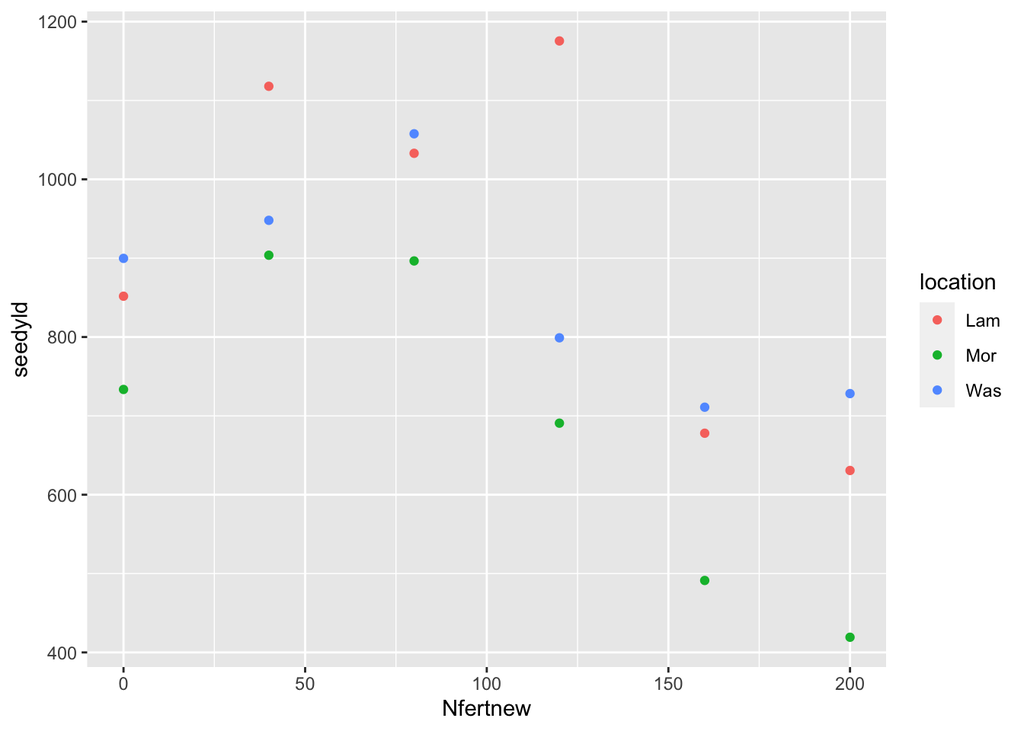

```r
ggplot(sumdat, aes(x=Nfertnew, y=seedyld, color=location))+
  geom_point()
```

Only adding points, but we will make each location a unique color as directed above. Now we’ll add error bars to the points from another column of information in that same dataset.

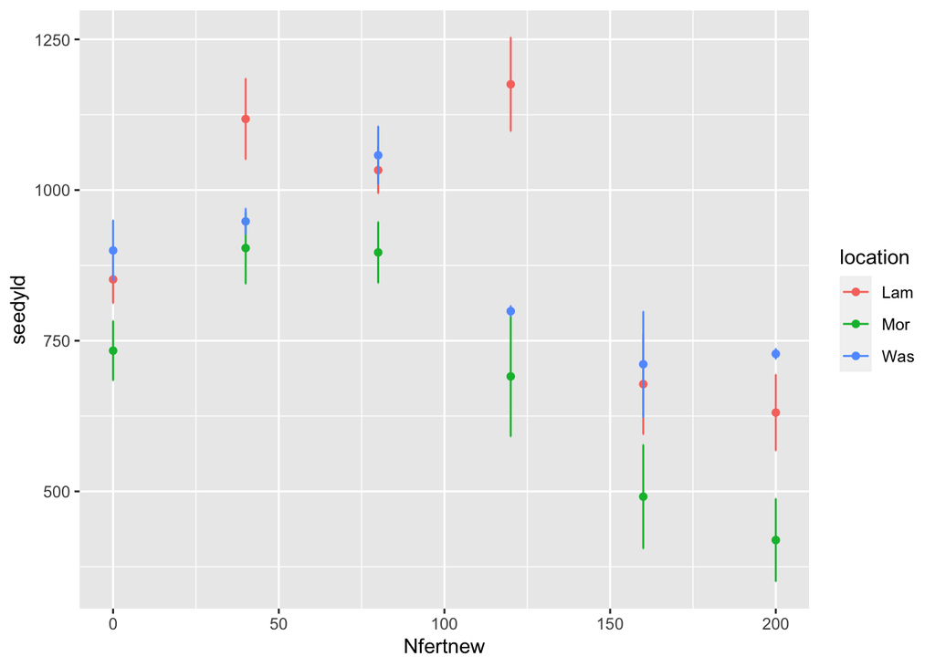

```r
ggplot(sumdat, aes(x=Nfertnew, y=seedyld, color=location))+
  geom_point()+
  geom_errorbar(aes(ymin=seedyld-se, ymax=seedyld+se), width=0.2)
```

Note you can use the standard error, standard deviation, or 95% confidence interval for an errorbar as the summarySE function provides all 3.

Now let’s plot the data in other ways. First, treat N fertilizer as a categorical variable and draw some bar graphs, one for each location. Again, we use the summarySE() function to summarize the data into the groups we’re interested in.

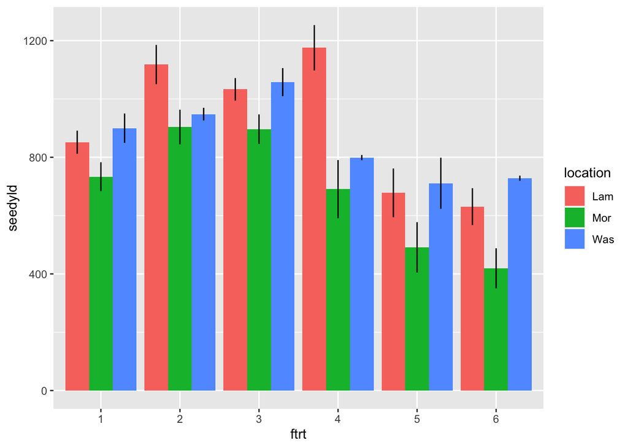

```r
sumdat2<-summarySE(dat, measurevar = "seedyld", groupvars=c("ftrt", "location"), na.rm=T)

ggplot(sumdat2, aes(x=ftrt, y=seedyld, fill=location))+
  geom_bar(position=position_dodge(), #puts the bars next to each other
           stat="identity") +
  geom_errorbar(aes(ymin=seedyld-se, ymax=seedyld+se),
                width=0, #This changes how wide the horizontal part of the errorbar is.
                position=position_dodge(.9)) #0.9 centers the error bars correctly.
```

Let’s make a figure with three panels, one for each location. Use the facet_grid() or facet_wrap() commands. Both have interesting functions.

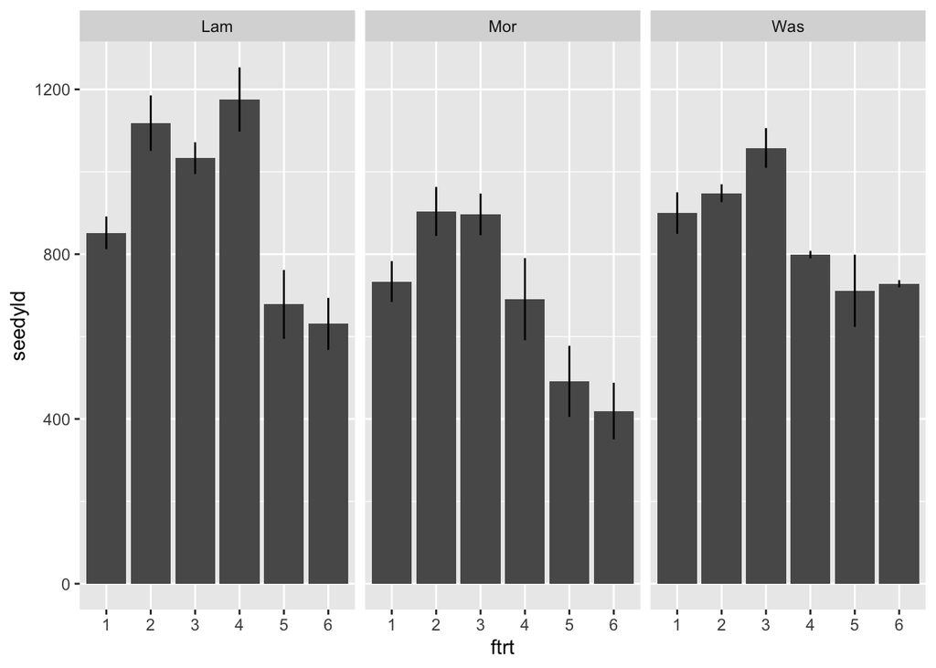

```r
ggplot(sumdat2, aes(x=ftrt, y=seedyld))+
  facet_wrap(~location)+ #use one or the other, facet_wrap or facet_grid. Read the internet about pros and cons to both.
  #facet_grid(~location, col=1)+
  geom_bar(position=position_dodge(), #puts the bars next to each other
           stat="identity") +
  geom_errorbar(aes(ymin=seedyld-se, ymax=seedyld+se),
                width=0,
                position=position_dodge(.9))
```

There are so many ways to customize your plots.

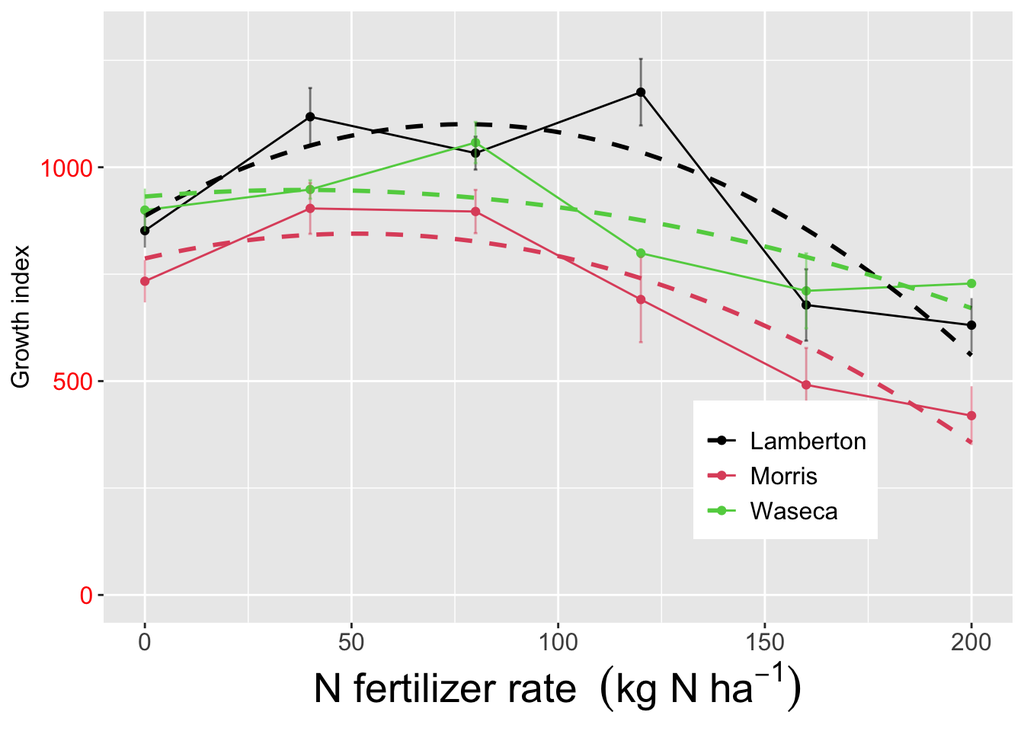

```r
ggplot(sumdat, aes(x=Nfertnew, y=seedyld, color=location))+
  geom_line()+ #order doesn't usually matter, but sometimes. geom_line simply connects the points
  geom_point()+
  stat_smooth(linetype=2,method = lm, formula = y ~ x + I(x^2), size = 1, se=FALSE)+ #I also changed the linetype and size in here. Note that it's applied to all the levels of your factor. Putting it in aes() would give you a unique linetype or size for each factor level (location in this case)
  geom_errorbar(alpha = 0.5, width=0.9, aes(ymin=seedyld-se, ymax=seedyld+se))+ #alpha makes things more transparent
  xlab(expression("N fertilizer rate " ~ ("kg N" ~ ha^{-1})))+ #use the expression() function to exponentiate characters in x axis label.
  ylab("Growth index")+
  scale_x_continuous(limits=c(0,200), breaks=c(0,50,100,150,200))+ #Control x axis
  ylim(c(0,1300))+
  scale_color_manual(name="Location", values=c(1:3), labels=c("Lamberton", "Morris", "Waseca"))+ #This is important. This gives you control of the aes parameter that controls how your data are separated. If you adjust the "color" option in the aes, then it's scale_color_manual. If you adjust the fill option, like we did for the bar graph, then it's scale_fill_manual. Note that you can relable your levels and retitle the legend here.
  theme( #This is where you can control many of the plot details.
    legend.key = element_rect(colour = NA, fill = NA),
    legend.position=c(.75,.25),# the numbers are % of x and y axis. So c(0.1,0.1) would place the legend in the bottom left hand corner
    legend.text=element_text(size=12),
    legend.title=element_blank(), #turn this on and off with comment to see how it works
    axis.text.x=element_text(size=12),
    axis.text.y=element_text(size=12, color="red"),
    axis.title.x=element_text(size=20),
    axis.title.y = element_text(size=12))
```

## 1.3 Fitting lines to data

Let’s go back to N fertilizer as a continuous variable. We’ll work with sumdat ggplot can fit functions to the data without having to create the linear model outside ggplot

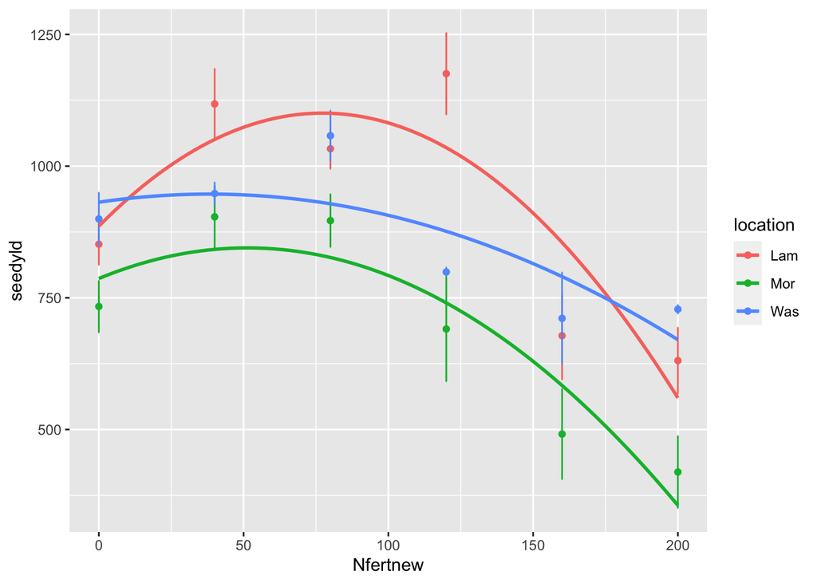

```r
ggplot(sumdat, aes(x=Nfertnew, y=seedyld, color=location))+
  geom_point()+
  geom_errorbar(aes(ymin=seedyld-se, ymax=seedyld+se), width=0.2)+
  stat_smooth(method = lm, formula = y ~ x + I(x^2), se=FALSE)
```

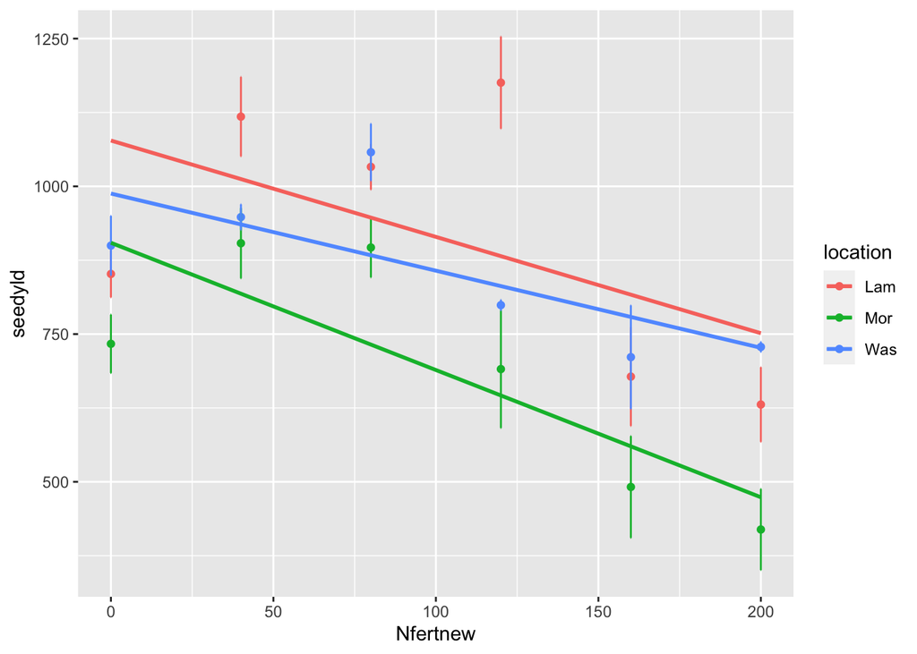

```r
ggplot(sumdat, aes(x=Nfertnew, y=seedyld, color=location))+
  geom_point()+
  geom_errorbar(aes(ymin=seedyld-se, ymax=seedyld+se), width=0.2)+
  stat_smooth(method = lm, formula = y ~ x, se=F) #see the difference in syntax here?
```

## 1.4 Fitting models to the data

It looks like a curved function is going to fit best. However, we’ll fit a linear function as well just to test it out.

First, we’ll fit equations for each location, treating them independently. Then, we’ll treat location as a random effect and find the best fitting equation to model yield responses to N across all three locations.

```r
mod1<-lme(seedyld~Nfertnew*location, random=~1|rep, data=dat)# linear model
mod2<-lme(seedyld~(Nfertnew+I(Nfertnew^2))*location, random=~1|rep, data=dat) #quadratic model. Note the weird notation for the quadratic term
anova(mod1)
```

```
##                   numDF denDF   F-value p-value
## (Intercept)           1    63 1561.6173  <.0001
## Nfertnew              1    63   31.1598  <.0001
## location              2    63   10.6123  0.0001
## Nfertnew:location     2    63    0.6608  0.5200
```

```r
anova(mod2)
```

```
##                        numDF denDF   F-value p-value
## (Intercept)                1    60 2303.0039  <.0001
## Nfertnew                   1    60   45.9531  <.0001
## I(Nfertnew^2)              1    60   28.4789  <.0001
## location                   2    60   15.6505  <.0001
## Nfertnew:location          2    60    0.9745  0.3833
## I(Nfertnew^2):location     2    60    2.9275  0.0612
```

Look at model coefficients

```r
summary(mod1)
```

```
## Linear mixed-effects model fit by REML
##   Data: dat
##        AIC      BIC    logLik
##   930.3229 947.8401 -457.1614
##
## Random effects:
##  Formula: ~1 | rep
##         (Intercept) Residual
## StdDev: 0.009231158 176.1416
##
## Fixed effects:  seedyld ~ Nfertnew * location
##                          Value Std.Error DF   t-value p-value
## (Intercept)          1077.5357  63.74096 63 16.904917  0.0000
## Nfertnew               -1.6304   0.52632 63 -3.097632  0.0029
## locationMor          -173.0476  90.14334 63 -1.919694  0.0594
## locationWas           -89.7262  90.14334 63 -0.995372  0.3234
## Nfertnew:locationMor   -0.5229   0.74433 63 -0.702450  0.4850
## Nfertnew:locationWas    0.3252   0.74433 63  0.436872  0.6637
##  Correlation:
##                      (Intr) Nfrtnw lctnMr lctnWs Nfrt:M
## Nfertnew             -0.826
## locationMor          -0.707  0.584
## locationWas          -0.707  0.584  0.500
## Nfertnew:locationMor  0.584 -0.707 -0.826 -0.413
## Nfertnew:locationWas  0.584 -0.707 -0.413 -0.826  0.500
##
## Standardized Within-Group Residuals:
##         Min          Q1         Med          Q3         Max
## -2.00792190 -0.64111705  0.01517313  0.57477770  2.66891608
##
## Number of Observations: 72
## Number of Groups: 4
```

```r
summary(mod2)
```

```
## Linear mixed-effects model fit by REML
##   Data: dat
##        AIC      BIC    logLik
##   931.5916 955.1661 -454.7958
##
## Random effects:
##  Formula: ~1 | rep
##         (Intercept) Residual
## StdDev:  0.00790132 145.0447
##
## Fixed effects:  seedyld ~ (Nfertnew + I(Nfertnew^2)) * location
##                              Value Std.Error DF   t-value p-value
## (Intercept)               886.0179  65.72897 60 13.479869  0.0000
## Nfertnew                    5.5516   1.54566 60  3.591701  0.0007
## I(Nfertnew^2)              -0.0359   0.00742 60 -4.840687  0.0000
## locationMor               -99.4018  92.95480 60 -1.069356  0.2892
## locationWas                45.4821  92.95480 60  0.489293  0.6264
## Nfertnew:locationMor       -3.2846   2.18590 60 -1.502620  0.1382
## Nfertnew:locationWas       -4.7451   2.18590 60 -2.170793  0.0339
## I(Nfertnew^2):locationMor   0.0138   0.01049 60  1.316227  0.1931
## I(Nfertnew^2):locationWas   0.0254   0.01049 60  2.416497  0.0187
##  Correlation:
##                           (Intr) Nfrtnw I(Nf^2) lctnMr lctnWs Nfrt:M Nfrt:W
## Nfertnew                  -0.763
## I(Nfertnew^2)              0.602 -0.960
## locationMor               -0.707  0.539 -0.426
## locationWas               -0.707  0.539 -0.426   0.500
## Nfertnew:locationMor       0.539 -0.707  0.679  -0.763 -0.381
## Nfertnew:locationWas       0.539 -0.707  0.679  -0.381 -0.763  0.500
## I(Nfertnew^2):locationMor -0.426  0.679 -0.707   0.602  0.301 -0.960 -0.480
## I(Nfertnew^2):locationWas -0.426  0.679 -0.707   0.301  0.602 -0.480 -0.960
##                           I(N^2):M
## Nfertnew
## I(Nfertnew^2)
## locationMor
## locationWas
## Nfertnew:locationMor
## Nfertnew:locationWas
## I(Nfertnew^2):locationMor
## I(Nfertnew^2):locationWas  0.500
##
## Standardized Within-Group Residuals:
##         Min          Q1         Med          Q3         Max
## -2.70249176 -0.47179417 -0.03896582  0.45872554  2.18479425
##
## Number of Observations: 72
## Number of Groups: 4
```

We can also compare our quadratic model to a model developed using the poly() function. You must include the “raw=TRUE” argument to get coefficients that make sense. You’ll see that they are exactly the same as the quadratic fit in mod2 above.

```r
mod3<-lme(seedyld~poly(Nfertnew, degree=2, raw=TRUE)*location, random=~1|rep, data=dat)
summary(mod3)
```

```
## Linear mixed-effects model fit by REML
##   Data: dat
##        AIC      BIC    logLik
##   931.5916 955.1661 -454.7958
##
## Random effects:
##  Formula: ~1 | rep
##         (Intercept) Residual
## StdDev: 0.007902083 145.0447
##
## Fixed effects:  seedyld ~ poly(Nfertnew, degree = 2, raw = TRUE) * location
##                                                        Value Std.Error DF
## (Intercept)                                         886.0179  65.72897 60
## poly(Nfertnew, degree = 2, raw = TRUE)1               5.5516   1.54566 60
## poly(Nfertnew, degree = 2, raw = TRUE)2              -0.0359   0.00742 60
## locationMor                                         -99.4018  92.95480 60
## locationWas                                          45.4821  92.95480 60
## poly(Nfertnew, degree = 2, raw = TRUE)1:locationMor  -3.2846   2.18590 60
## poly(Nfertnew, degree = 2, raw = TRUE)2:locationMor   0.0138   0.01049 60
## poly(Nfertnew, degree = 2, raw = TRUE)1:locationWas  -4.7451   2.18590 60
## poly(Nfertnew, degree = 2, raw = TRUE)2:locationWas   0.0254   0.01049 60
##                                                       t-value p-value
## (Intercept)                                         13.479869  0.0000
## poly(Nfertnew, degree = 2, raw = TRUE)1              3.591701  0.0007
## poly(Nfertnew, degree = 2, raw = TRUE)2             -4.840687  0.0000
## locationMor                                         -1.069356  0.2892
## locationWas                                          0.489293  0.6264
## poly(Nfertnew, degree = 2, raw = TRUE)1:locationMor -1.502620  0.1382
## poly(Nfertnew, degree = 2, raw = TRUE)2:locationMor  1.316227  0.1931
## poly(Nfertnew, degree = 2, raw = TRUE)1:locationWas -2.170793  0.0339
## poly(Nfertnew, degree = 2, raw = TRUE)2:locationWas  2.416497  0.0187
##  Correlation:
##                                                     (Intr) pl(N,d=2,r=TRUE)1
## poly(Nfertnew, degree = 2, raw = TRUE)1             -0.763
## poly(Nfertnew, degree = 2, raw = TRUE)2              0.602 -0.960
## locationMor                                         -0.707  0.539
## locationWas                                         -0.707  0.539
## poly(Nfertnew, degree = 2, raw = TRUE)1:locationMor  0.539 -0.707
## poly(Nfertnew, degree = 2, raw = TRUE)2:locationMor -0.426  0.679
## poly(Nfertnew, degree = 2, raw = TRUE)1:locationWas  0.539 -0.707
```

[output cut: 29 more lines]

```
## poly(Nfertnew, degree = 2, raw = TRUE)1
## poly(Nfertnew, degree = 2, raw = TRUE)2
## locationMor
## locationWas
## poly(Nfertnew, degree = 2, raw = TRUE)1:locationMor
## poly(Nfertnew, degree = 2, raw = TRUE)2:locationMor
## poly(Nfertnew, degree = 2, raw = TRUE)1:locationWas
## poly(Nfertnew, degree = 2, raw = TRUE)2:locationWas -0.960
##
## Standardized Within-Group Residuals:
##         Min          Q1         Med          Q3         Max
## -2.70249176 -0.47179417 -0.03896582  0.45872554  2.18479425
##
## Number of Observations: 72
## Number of Groups: 4
```

We’ll use ggplot to fit a poly() smoother line through the points and again you’ll see that it’s exactly the same as the mod2 line in the ggplot figure above.

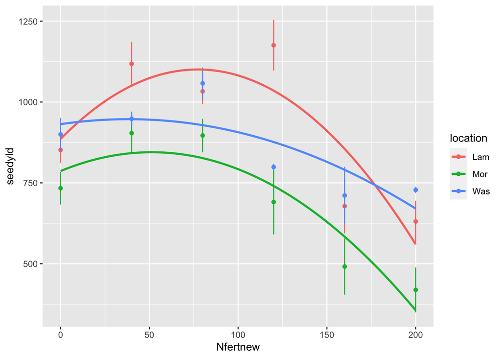

```r
ggplot(sumdat, aes(x=Nfertnew, y=seedyld, color=location))+
  geom_point()+
  geom_errorbar(aes(ymin=seedyld-se, ymax=seedyld+se), width=0.2)+
  stat_smooth(method = lm, formula = y ~ poly(x,2), se=F)
```

Now that we understand how the poly() function compares, we’ll proceed with the manual quadratic fit. Back to mod1 and mod2…

There’s no N rate X location interaction for either model (mod1 or mod2), so I wouldn’t treat each location independently, but for demonstration we’ll do it anyway.

Subset the locations.

```r
Lamdat<-droplevels(subset(dat, location=="Lam")) #always droplevels() when subsetting, sometimes the old levels end up in the new dataset.
Wasdat<-droplevels(subset(dat, location=="Was"))
Mordat<-droplevels(subset(dat, location=="Mor"))
```

Manually create two models, a linear and quadratic, for each location; I’ll just do lamberton

```r
Lammod1<-lme(seedyld~Nfertnew, random=~1|rep, data=Lamdat)
Lammod2<-lme(seedyld~Nfertnew+I(Nfertnew^2), random=~1|rep, data=Lamdat)
```

Compare using liklihood ratio test

```r
anova(Lammod1, Lammod2) # Note that REML (restricted maximum liklihood) methods are not meaningful, so switch to ML (maximum liklihood)
```

```
##         Model df      AIC      BIC    logLik   Test  L.Ratio p-value
## Lammod1     1  4 322.3238 326.6879 -157.1619
## Lammod2     2  5 318.1982 323.4209 -154.0991 1 vs 2 6.125522  0.0133
```

```r
Lammod1.ml<-update(Lammod1, method="ML")
Lammod2.ml<-update(Lammod2, method="ML")
anova(Lammod1.ml, Lammod2.ml)
```

```
##            Model df      AIC      BIC    logLik   Test  L.Ratio p-value
## Lammod1.ml     1  4 332.6602 337.3724 -162.3301
## Lammod2.ml     2  5 319.5178 325.4081 -154.7589 1 vs 2 15.14242   1e-04
```

Lammod2.ml, the quadratic model, is far superior. AIC is much lower, and L.ratio is significant based on alpha=0.05

## 1.5 Rearranging equations - Find the peak of the curve

Now the tough part, identifying the AONR, or the x value of this curve where y value peaks. The way to do this is to set the derivitive of the function to 0 (no slope, or flat), and solve for x. Let’s say our quadratic model is

y = alpha + beta*x + gamma*x^2

Let’s call this x value ANOR. So we’ll rearrange the equation to solve for beta.

beta = -2*gamma*AONR

Now substitute this for beta in our original quadratic equation so that the AONR is in it

y = alpha - ((2*gamma*AONR)*x) + gamma*x^2

This is our new equation with AONR as a coefficient. R can solve for this coefficient and provide an estimate of variance for that coefficient.

Use the nls() function to fit your data to the new equation above. First, define the function

```r
qmmod<-function(x, alpha, AONR, gamma){
  alpha - ((2*gamma*AONR)*x)+(gamma*x^2)
}
```

Use nls. The tricky part is that you need to provide an estimate of what the coefficients will be to help. R know where to start searching.

```r
Lammod.q<-nls(seedyld ~ qmmod(Nfertnew, alpha, AONR, gamma), data=Lamdat,
    start = list(alpha = 700, AONR = 60, gamma = -0.01), #by looking at the figure, we can see that the y intercept (or alpha) is about 800, the peak of the curve might be around 60.
    control = list(maxiter=200))                        #The third coefficient, gamma, is trickier to guess. I use trial and error, but now I know it's usually around -0.01

summary(Lammod.q) #It works; R gives us an estimate of 77.3 kg N per ha for maximizing grain yields. Let's plot
```

```
##
## Formula: seedyld ~ qmmod(Nfertnew, alpha, AONR, gamma)
##
## Parameters:
##         Estimate Std. Error t value Pr(>|t|)
## alpha 886.017858  74.040511  11.967 7.66e-11 ***
## AONR   77.299145   8.609020   8.979 1.23e-08 ***
## gamma  -0.035910   0.008356  -4.297 0.000319 ***
## ---
## Signif. codes:  0 '***' 0.001 '**' 0.01 '*' 0.05 '.' 0.1 ' ' 1
##
## Residual standard error: 163.4 on 21 degrees of freedom
##
## Number of iterations to convergence: 3
## Achieved convergence tolerance: 7.301e-09
```

However, this does not have our random effects in it. You can use nlme() to fit a random effects model with custom functions

```r
ranLammod.q<-nlme(seedyld ~ qmmod(Nfertnew, alpha, AONR, gamma),
     data=Lamdat,
     fixed=alpha+AONR+gamma~1,
     random=alpha~1|rep,
     method="ML",
     control=nlmeControl(pnlsTol = 0.1, verbose=T),
     start=c(alpha=700, gamma=-0.01, AONR=60),
     na.action=na.omit)
summary(ranLammod.q) #Very similar results for fixed effects coefficients, and we see that the variation explained
```

```
## Nonlinear mixed-effects model fit by maximum likelihood
##   Model: seedyld ~ qmmod(Nfertnew, alpha, AONR, gamma)
##   Data: Lamdat
##        AIC      BIC    logLik
##   319.5178 325.4081 -154.7589
##
## Random effects:
##  Formula: alpha ~ 1 | rep
##               alpha Residual
## StdDev: 0.007264974 152.8335
##
## Fixed effects:  alpha + AONR + gamma ~ 1
##          Value Std.Error DF   t-value p-value
## alpha 886.0161  74.04051 18 11.966639   0e+00
## AONR   77.2982   8.60930 18  8.978450   0e+00
## gamma  -0.0359   0.00836 18 -4.297216   4e-04
##  Correlation:
##       alpha  AONR
## AONR  -0.890
## gamma  0.602 -0.614
##
## Standardized Within-Group Residuals:
##        Min         Q1        Med         Q3        Max
## -2.5646849 -0.4525609 -0.1741983  0.5281194  2.0735341
##
## Number of Observations: 24
## Number of Groups: 4
```

```r
#by our random effect is very small.
```

Create a fake dataset to fit your new function to. Make sure the column names are exactly the same as your original data. You need all the columns too, including random effect.

```r
plotdat<-data.frame(expand.grid(Nfertnew=c(0:200), rep=NA, location=NA,  seedyld=NA))
plotdat$seedyld<-predict(ranLammod.q, plotdat, level=0) #use your model to predict seed yield at all N fert levels between 0 and 200, and add those predictions to your new fake data frame.
```

What we’re really interested in is the seed yield estimate at the predicted AONR

```r
lamaonr<-ranLammod.q$coefficient$fixed[2] #This pulls out the second fixed effect coefficient from the model, or our AONR
AONRpt<-data.frame("AONR"=lamaonr,
                   "AONRse"=summary(ranLammod.q)$tTable[2,2], #This extracts the Std. Error of AONR
                   "seedyld"= predict(ranLammod.q, data.frame(Nfertnew=lamaonr), level=0))
```

Make the same plot as before, but we’ll add the new line in the fake data set with predictions

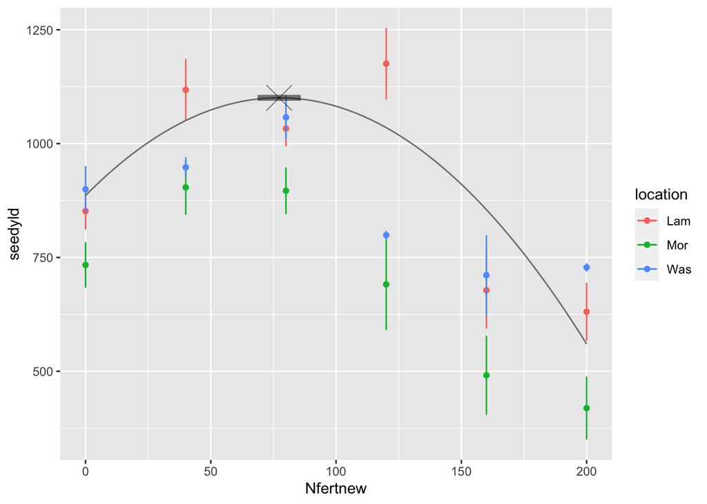

```r
ggplot(sumdat, aes(x=Nfertnew, y=seedyld))+
  geom_point(aes(color=location))+
  geom_errorbar(aes(ymin=seedyld-se, ymax=seedyld+se, color=location), width=0.2)+
  geom_line(data=plotdat, aes(color=location))+
  geom_point(data=AONRpt, aes(x=AONR, y=seedyld), shape=4, size=8, alpha=.5)+ # the X indicates the ANOR and estimated yield
  geom_segment(data=AONRpt, aes(x=AONR-AONRse, y=seedyld, xend=AONR+AONRse, yend=seedyld),
               alpha=.5, linetype=1, size=2, color="black") #The line indicates the AONR range based on standard error
```

Here’s a function to do this easily, but now I’m including location as random effect, with rep nested in each location

```r
qmmod<-function(x, alpha, AONR, gamma){
  alpha - ((2*gamma*AONR)*x)+(gamma*x^2)
}

auto.aonr<-function(dataset){
  m1<-lme(seedyld~Nfertnew, random=~1|location/rep, data=dataset, na.action=na.omit, method="ML")
  m2<-lme(seedyld~Nfertnew+I(Nfertnew^2), random=~1|location/rep, data=dataset, na.action=na.omit, method="ML")
  if(selMod(list(m1,m2))[1,3]>selMod(list(m1,m2))[2,3]){ #if model 2 has a lower AICc, the make the nls model and print
    grdat<-dataset[,c("location","plot","rep","Nfertnew","seedyld")]
    grdat<-groupedData(seedyld~Nfertnew|location/rep/plot, data=grdat,
                       labels=list(x='Nitrogen rate', y="Grain Yield"),
                       units=list(x="(kg2/ha)", y="(kg2/ha)"))

    m3<-nlme(seedyld ~ qmmod(Nfertnew, alpha, AONR, gamma),
             data=grdat,
             fixed=alpha+AONR+gamma~1,
             random=alpha~1|location/rep,
             method="ML",
             control=nlmeControl(pnlsTol = 0.01, verbose=T, maxIter=1000),
             start=c(alpha=800, gamma=-0.01, AONR=100),
             na.action=na.omit)

    AONRtab<-data.frame("AONR"=m3$coefficient$fixed[2],
                       "AONRse"=summary(m3)$tTable[2,2], #This extracts the Std. Error of AONR
                       "seedyld"= predict(m3, data.frame(Nfertnew=m3$coefficient$fixed[2]), level=0),
                       "Model Type"="Quadratic")
    print(AONRtab)
  }else{ #if the linear model is significantly better, just print those results
    AONRtab<-data.frame("AONR"=NA,
                        "AONRse"=NA,
                        "seedyld"= NA,
                        "Model Type"="Linear",
                        "Equation"=print("Y = ", m1$coefficients[1], " + X", m1$coefficients[2]))
  }
}
```

Run the function, here we see that the AONR is 62.89 kg N ha and predicted seed yield is 958 kg ha when using data from all locations and treating location as a random effect.

```r
auto.aonr(dat)
```

```
##          AONR   AONRse  seedyld Model.Type
## AONR 62.88825 9.158245 958.4447  Quadratic
```

That’s great, but what if yields plateau and don’t drop off with high N rates? What if a quadratic function isn’t optimal?

```r
#odat<-read.table("Otherdat.txt", header=T)
gs4_deauth()
odat<-read_sheet("https://docs.google.com/spreadsheets/d/13MFzCTktPfpC3-_YAQMlXjyd9F0D9pUyhGXSMK66kqs/edit?usp=sharing", na="NA")
```

```
## ✔ Reading from "Otherdat".
```

```
## ✔ Range 'Sheet1'.
```

```r
head(odat); str(odat)
```

```
## # A tibble: 6 × 7
##   site   year env    plot  Ntrt   rep    dm
##   <chr> <dbl> <chr> <dbl> <dbl> <dbl> <dbl>
## 1 Aus    2008 A08     101    56     1  5.08
## 2 Aus    2008 A08     102   112     1  6.75
## 3 Aus    2008 A08     103     0     1  5.95
## 4 Aus    2008 A08     104   224     1  8.15
## 5 Aus    2008 A08     105   168     1  7.56
## 6 Aus    2008 A08     106   168     1  9.26
```

```
## tibble [600 × 7] (S3: tbl_df/tbl/data.frame)
##  $ site: chr [1:600] "Aus" "Aus" "Aus" "Aus" ...
##  $ year: num [1:600] 2008 2008 2008 2008 2008 ...
##  $ env : chr [1:600] "A08" "A08" "A08" "A08" ...
##  $ plot: num [1:600] 101 102 103 104 105 106 107 108 109 110 ...
##  $ Ntrt: num [1:600] 56 112 0 224 168 168 224 56 224 56 ...
##  $ rep : num [1:600] 1 1 1 1 1 1 1 1 1 1 ...
##  $ dm  : num [1:600] 5.08 6.75 5.95 8.15 7.56 ...
```

```r
odat$fyear<-as.factor(odat$year);odat$fplot<-as.factor(odat$plot)
odat$fNtrt<-as.factor(odat$Ntrt); odat$frep<-as.factor(odat$rep)
```

Subset the data for simplicity

```r
head(odat)
```

```
## # A tibble: 6 × 11
##   site   year env    plot  Ntrt   rep    dm fyear fplot fNtrt frep
##   <chr> <dbl> <chr> <dbl> <dbl> <dbl> <dbl> <fct> <fct> <fct> <fct>
## 1 Aus    2008 A08     101    56     1  5.08 2008  101   56    1
## 2 Aus    2008 A08     102   112     1  6.75 2008  102   112   1
## 3 Aus    2008 A08     103     0     1  5.95 2008  103   0     1
## 4 Aus    2008 A08     104   224     1  8.15 2008  104   224   1
## 5 Aus    2008 A08     105   168     1  7.56 2008  105   168   1
## 6 Aus    2008 A08     106   168     1  9.26 2008  106   168   1
```

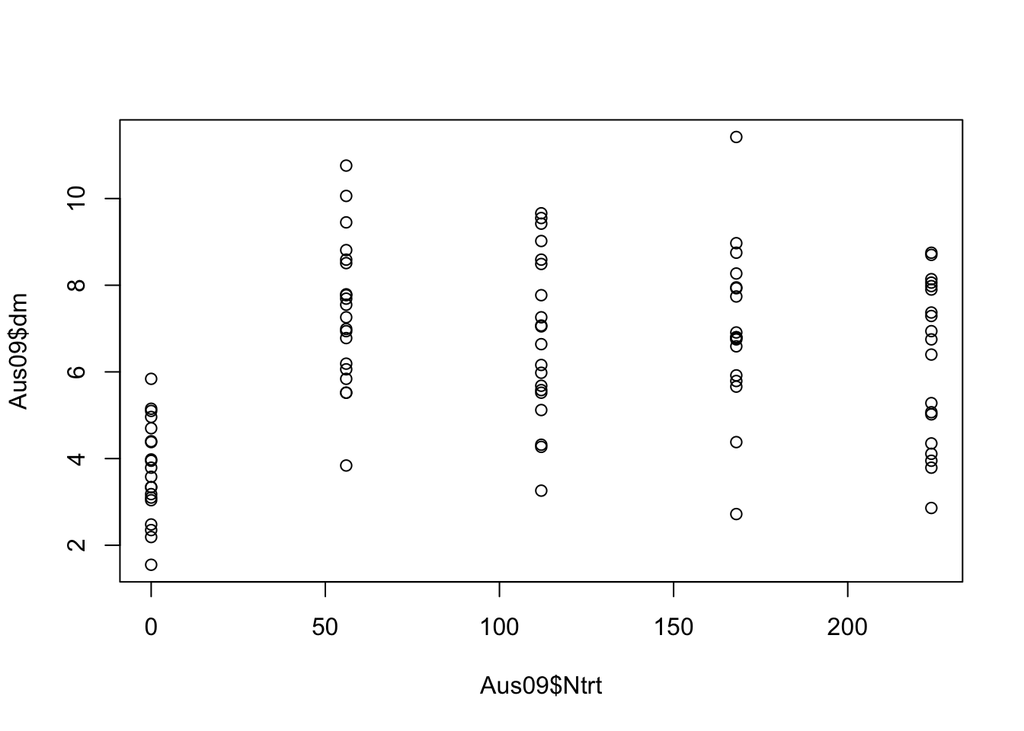

```r
Aus09 <- odat %>%
  filter(year=="2009"&site=="Aus")
#Aus09<-droplevels(subset(odat, odat$year=="2009"&odat$site=="Aus"))
plot(Aus09$dm ~ Aus09$Ntrt)
```

The square root quadratic plateau model has a nice plateau. The square root quadratic model is

y = alpha + beta*x + gamma*x^0.5

where alpha is y-intercept and beta and gamma are other coefficients

Setting the derivitive of this function to 0 would look like:

0=beta+(gamma/(2*sqrt(x)))

then solve for x, which is the point where y plateaus:

x = ((-gamma)/(2*beta))^2

Rename the x value here as AONR; then rearrange equation to solve for beta

beta = -gamma/(2*sqrt(AONR))

Now substitute this for beta in our original quadratic equation so that the AONR is in it

This is our new equation with AONR as a coefficient. R can solve for this coefficient and provide an estimate of variance for that coefficient.

Use the nls() function to fit your data to the new equation above.

```r
sqrtmod<-nls(dm ~ alpha - (((.5*gamma)/sqrt(AONR))*Ntrt)+(gamma*Ntrt^.5), data=Aus09,
                start = list(alpha = 4, AONR = 120, gamma = 140),
                control = list(maxiter=200))
```

Use nls. The tricky part is that you need to provide an estimate of what the coefficients will be to help. R know where to start searching. This isn’t too tricky the way that the equation is arranged now. alpha is the y intercept, so look at the plot to figure out about where that should be. You should also be able to give a good guess at what the AONR should be. Here I guessed 120

```r
coef(sqrtmod)
```

```
##      alpha       AONR      gamma
##  3.7588056 92.9004446  0.7306779
```

```r
#Or you can make a function and call that in nls()
sqrtfun<-function(x, alpha, AONR, gamma){
  alpha - (((.5*gamma)/sqrt(AONR))*x)+(gamma*x^.5)
}
```

Use nls. The tricky part is that you need to provide an estimate of what the coefficients will be to help R know where to start searching.

```r
sqrtmod2<-nls(dm ~ sqrtfun(Ntrt, alpha, AONR, gamma), data=Aus09,
              start = list(alpha = 4, AONR = 100, gamma = 100), #by looking at the figure, we can see that the y intercept (or alpha) is about 800, the peak of the curve might be around 60.
              control = list(maxiter=200))                        #The third coefficient, gamma, is trickier to guess. I use trial and error, but now I know it's usually around -0.01
coef(sqrtmod2)
```

```
##      alpha       AONR      gamma
##  3.7588056 92.9009722  0.7306779
```